# 4. Aggregate item-level linking (the classic analysis, updated)

peekbank-items

This notebook reproduces the **background failure** (`4A`: naive word-level LWL accuracy correlates with Wordbank AoA in the *wrong* direction) on 2026.1 data, then tests whether the two methodological fixes help **at the aggregate item level**:

1. a better LWL measure (animacy-adjusted random intercept vs raw accuracy);
2. a better CDI measure (IRT difficulty `b` vs AoA).

No child information enters here — this is the **“aggregate” data setting**, and it is the first of the three settings (aggregate / imputed / precise) that notebook 5 compares in a common trial-level framework. This notebook does the aggregate case thoroughly at the *word* level; notebook 5 picks it up at the *trial* level and adds the child-specific settings.

**What the measures are** (all per target word):

- `avg_accuracy` / `avg_elogit` — raw mean looking accuracy for the word, pooled over all trials. Badly confounded: a word’s average is dragged around by the ages and studies it happens to be tested in.
- `intercept_base` — the word’s random intercept from a mixed model (notebook 2) that controls for age (within dataset), child, dataset, and the distractor.
- `intercept_adj` — the same, but the model **also** removes target/distractor **animacy** (perceptual salience). This is our cleanest LWL difficulty measure: a word’s recognition ease with confounds partialled out. Higher = recognized better. (See `2_lwl_item_difficulty` for the model.)

The CDI-side difficulty is the IRT `b` and Wordbank `aoa` from notebook 3.

```r
library(here)
library(ggrepel)
library(patchwork)
source(here("helper", "common.R"))
knitr::opts_chunk$set(cache = FALSE)

lwl <- readRDS(here("cached_intermediates", "2_lwl_item.Rds"))
cdi <- readRDS(here("cached_intermediates", "3_cdi_difficulty.Rds"))

# CDI-side difficulty per word
cdi_diff <- cdi$item_pars |>
  select(item, a, b) |>
  left_join(cdi$aoas |> select(item, aoa), by = "item")

# LWL-side measures per word, merged with CDI difficulty
mdf <- lwl$lwl_word |>
  mutate(item = target_label) |>
  inner_join(cdi_diff, by = "item")
```

We have 121 words with both LWL and CDI measures.

## The naive failure: raw accuracy vs AoA

Direction we *want*: earlier-acquired (low AoA) words should be recognized **better** (high accuracy) → a **negative** slope.

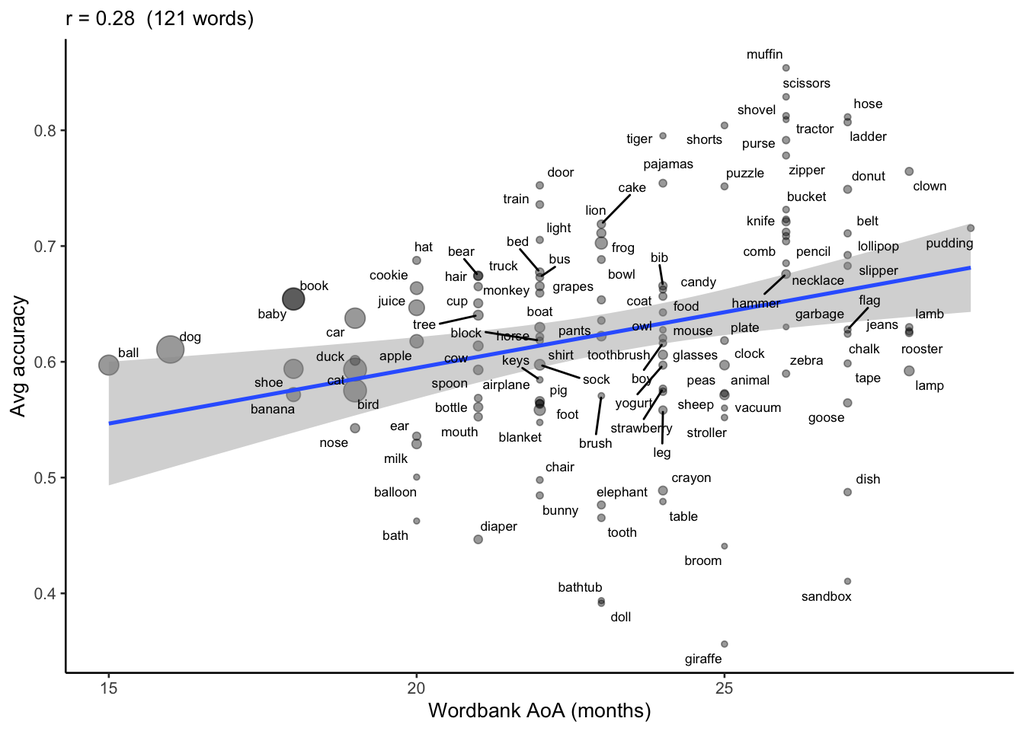

```r
plot_corr <- function(data, x, y, xlab, ylab, min_n = 0) {
  data <- dplyr::filter(data, n_trials >= min_n)
  r <- cor(data[[x]], data[[y]], use = "complete.obs")
  ggplot(data, aes(x = .data[[x]], y = .data[[y]])) +
    geom_point(aes(size = n_trials), alpha = .4) +
    geom_smooth(method = "lm") +
    geom_text_repel(aes(label = target_label), size = 2.3, max.overlaps = 8) +
    xlab(xlab) + ylab(ylab) +
    labs(subtitle = sprintf("r = %.2f  (%d words)", r, nrow(data))) +
    theme(legend.position = "none")
}

plot_corr(mdf, "aoa", "avg_accuracy", "Wordbank AoA (months)", "Avg accuracy")
```

As in the background analysis, this goes the **wrong way**: later-acquired words show *higher* accuracy, driven by age confounding (easy words are tested in younger samples) and salience.

## Fix 1: animacy-adjusted LWL difficulty

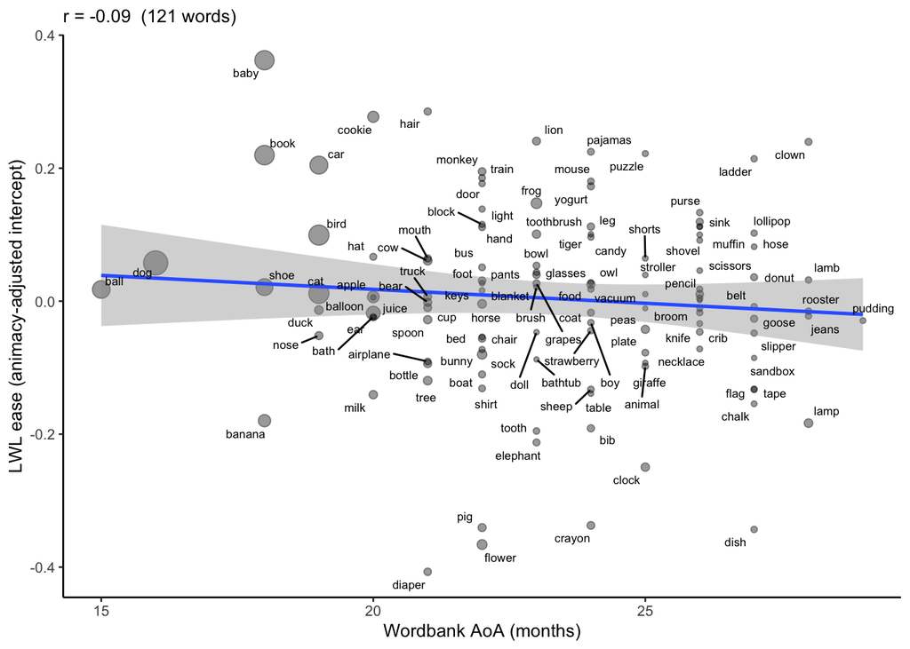

```r
plot_corr(mdf, "aoa", "intercept_adj",
          "Wordbank AoA (months)", "LWL ease (animacy-adjusted intercept)")
```

## Fix 2: IRT difficulty instead of AoA

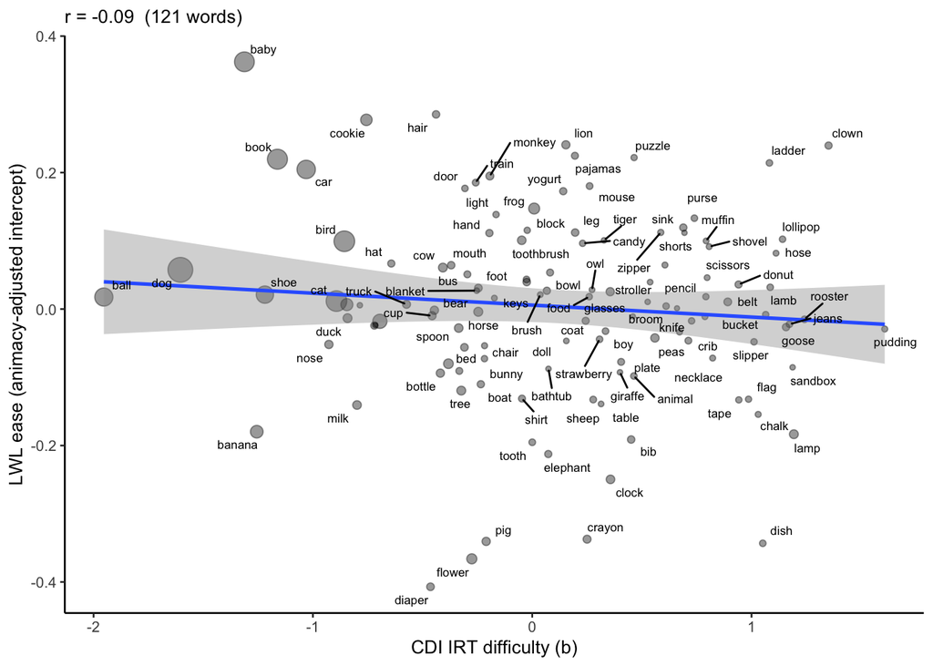

```r
plot_corr(mdf, "b", "intercept_adj",
          "CDI IRT difficulty (b)", "LWL ease (animacy-adjusted intercept)")
```

## Fix 3: restrict to well-estimated words

The plots above pool all 121 words, but most have very few trials, so their `intercept_adj` is a noisy estimate. Noise in a predictor **attenuates** correlations toward zero (classic measurement-error attenuation). Restricting to words with a lot of data (here, >200 trials) gives each word a reliable difficulty estimate — and this is where the relationship becomes clear and points the *right* way (harder/later-learned word ⇒ lower LWL ease ⇒ **negative** slope).

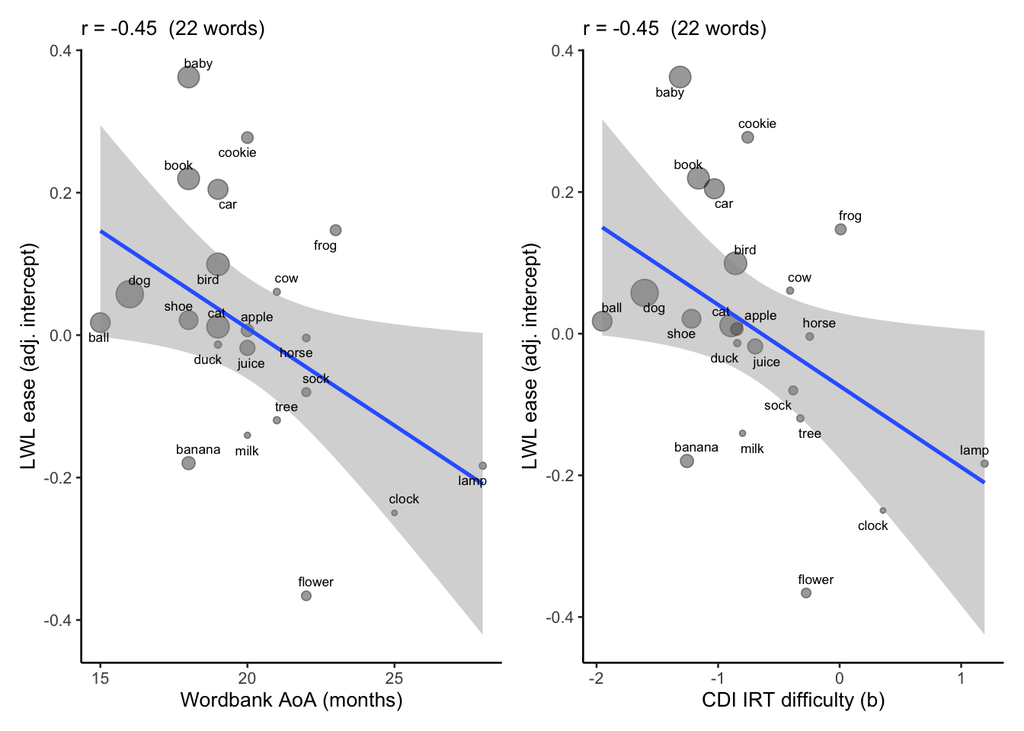

```r
library(patchwork)
p_aoa <- plot_corr(mdf, "aoa", "intercept_adj",
                   "Wordbank AoA (months)", "LWL ease (adj. intercept)", min_n = 200)
p_b <- plot_corr(mdf, "b", "intercept_adj",
                 "CDI IRT difficulty (b)", "LWL ease (adj. intercept)", min_n = 200)
p_aoa + p_b
```

It takes **both** moves. On the same well-estimated words, *raw accuracy* goes from the wrong-direction *r* ≈ +0.28 (all words) to roughly flat (*r* ≈ 0) — the frequency filter removes the confound but leaves no positive linkage — whereas the *adjusted intercept* reaches *r* ≈ −0.45. So the frequency filter cleans up the predictor and the LWL-side modeling supplies the actual signal.

## Summary of correlations

All cells are correlations of an LWL measure with a CDI difficulty measure. **Success = negative** (harder/later word ⇒ lower LWL ease). The naive cell (top-left, `avg_accuracy` × `aoa`) is the one the background found positive.

```r
lwl_measures <- c("avg_accuracy", "avg_elogit", "intercept_base", "intercept_adj")
cdi_measures <- c("aoa", "b")

grid <- expand_grid(lwl = lwl_measures, cdi = cdi_measures, hf_only = c(FALSE, TRUE))

results <- grid |>
  rowwise() |>
  mutate(
    r = {
      d <- if (hf_only) filter(mdf, n_trials > 200) else mdf
      cor(d[[lwl]], d[[cdi]], use = "complete.obs")
    },
    n_words = if (hf_only) sum(mdf$n_trials > 200) else nrow(mdf)
  ) |>
  ungroup()

results |>
  mutate(cell = paste0(cdi, ifelse(hf_only, " (n>200)", ""))) |>
  select(lwl, cell, r) |>
  pivot_wider(names_from = cell, values_from = r) |>
  kable(digits = 2, caption = "Correlation of LWL measure (rows) with CDI difficulty (cols). Negative = success.")
```

Correlation of LWL measure (rows) with CDI difficulty (cols). Negative = success.

| lwl | aoa | aoa (n>200) | b | b (n>200) |
| --- | --- | --- | --- | --- |
| avg_accuracy | 0.28 | 0.01 | 0.27 | 0.03 |
| avg_elogit | 0.29 | 0.00 | 0.28 | 0.01 |
| intercept_base | -0.11 | -0.41 | -0.11 | -0.39 |
| intercept_adj | -0.09 | -0.45 | -0.09 | -0.45 |

## Read

The table makes the diagnosis concrete. Reading the `intercept_adj` row under the `(n>200)` columns: with a clean LWL measure **and** well-estimated words, the aggregate item-level correlation finally points the right way (≈ −0.45). The naive cell (`avg_accuracy` × `aoa`, all words) is the +0.28 failure the background reported. IRT `b` and `aoa` behave almost identically (they correlate ~0.99; see notebook 3), so the CDI-side measure is *not* the lever — the LWL-side modeling and the frequency filter are.

But even at its best, the aggregate level throws away the within-child structure: a child only “knows” a word probabilistically, and the 2AFC decision could depend on the *distractor* too. **Notebook 5** carries this same aggregate analysis to the trial level and adds the child-specific settings (imputed and precise word knowledge) in one common framework; **notebook 6** drills into the precise, within-child item-specific test.